# Chronic Diseases and Their Relationship with Unhealthy Behaviors and Preventative Measures

Ali Mohamud, Jeremy James, Ben Donovan

December 12, 2018

## Introduction

What is a chronic disease?

- a chronic disease is a disease that persists for a long time (3 months +)
- they are generally not prevented by vaccines nor do they go away with medication or time.
- they have no cure.
- chronic diseases affect millions of Americans every day.

In this project, we:

- analyzed measures of chronic diseases, including unhealthy behaviors, health outcomes, and use of preventive services of 500 major cities in the United States
- found the correlations between specific unhealthy behaviors or preventative services and chronic diseases.
- identified which communities thrive or suffer from specific chronical deseases using a map product

## Description of the Data

- the data that we used in this project is the’500 Cities: Local Data for Better Health’ that we obtained from the CDC’s
- this is a publicaly available data set that includes a model-based small area estimates for 27 measures of chronic disease related to unhealthy behaviors (5), heath outcomes (13) and use of preventive services (9) for 500 cities throughout the United States
- the primary aim of the data is to make it possible to identify emerging health problems and effective interventions at city level

## The chronic diseases tracked in our data set.

Conditions and description of measure

| Chronic Disease | Data Set Measures |
| --- | --- |
| Arthritis | Arthritis among adults aged >=18 Years |
| High Blood Pressure | High blood pressure among adults aged >=18 Years |
| Cancer (except skin) | Cancer (excluding skin cancer) among adults aged >=18 Years |
| Current Asthma | Current asthma among adults aged >=18 Years |
| Coronary Heart Disease | Coronary heart disease among adults aged >=18 Years |
| COPD | Chronic obstructive pulmonary disease among adults aged >=18 Years |

## Unhealthy behaviors tracked in our data set

Unhealthy behaviors and description of measure

| Unhealthy Behavior | Data Set Measures |
| --- | --- |
| Binge Drinking | Binge drinking among adults aged >=18 Years |
| Current Smoking | Current smoking among adults aged >=18 Years |
| Physical Inactivity | No leisure-time physical activity among adults aged >=18 Years |
| Obesity | Obesity among adults aged >=18 Years |
| Sleep <7 hours | Sleeping less than 7 hours among adults aged >=18 Years |

## preventive services tracked in our data set

Preventive service and description of measure

| Preventive Service | Data Set Measures |
| --- | --- |
| Health Insurance | Current lack of health insurance among adults aged 18-64 Years |
| Taking BP Medication | Taking medicine for high blood pressure control among adults aged >=18 Years with high blood pressure |
| Annual Checkup | Visits to doctor for routine checkup within the past Year among adults aged >=18 Years |
| Cholesterol Screening | Cholesterol screening among adults aged >=18 Years |
| Colorectal Cancer Screening | Fecal occult blood test, sigmoidoscopy, or colonoscopy among adults aged 50-75 Years |
| Pap Smear Test | Papanicolaou smear use among adult women aged 21-65 Years |

## Data preparation

- rearranged the data to allow us to create graphs and provide better analysis
- created three different data frames for health outcomes, prevention and unhealthy behavior
- to account for missing entries, we used the mice package to impute data

## Data Exploration

We Created:

- a shiny dashboard to easily map chronic diseases and generate useful scatter plots
- a correlation matrix to find the relationship between preventative measures and chronic diseases

This is a map plot that shows arthritis rates accross the country.

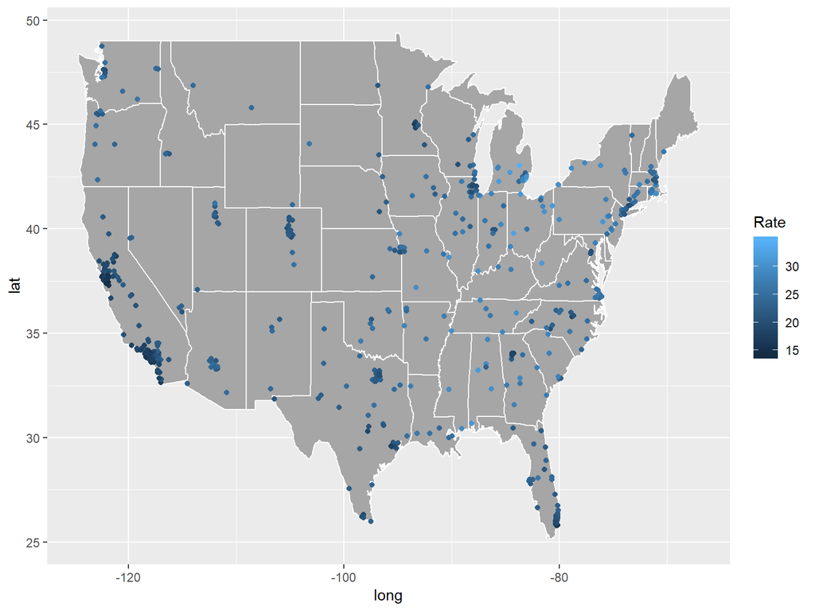

- to find the relationship between measures, We constructed a graphical correlation matrix
- this matrix below shows the correlation between each pair of measures
- the correlation value is the Pearson correlation coefficient

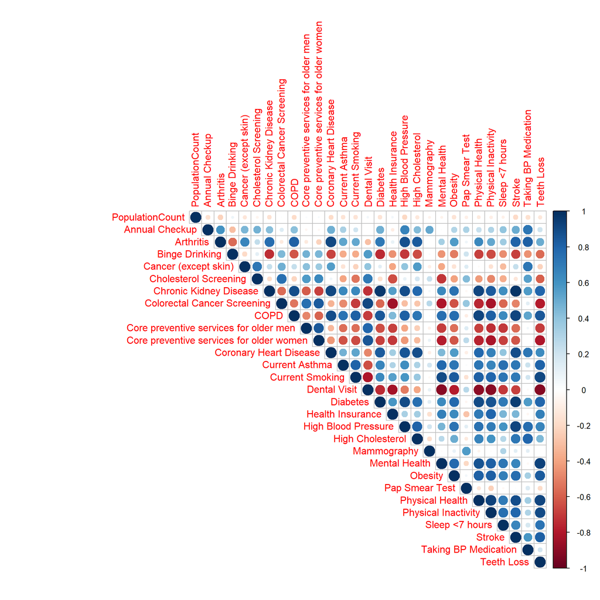

## Data Products

In this project we made, three data products using the shiny package.

1. a map generator to show the location of healthy or unhealthy cities, which reveals regional differences in disease rates
2. two scatter plot generators to show the user:
   - the correlation between different measures
   - the rate of the chronic diseases by state
- the following is link to the Shiny App: https://jeremyjames.shinyapps.io/cdc500citiesshinyapp/
- all three data products were generated in order to effectively analyze measures of chronic diseases, including unhealthy behaviors, health outcomes, and use of preventative services of 500 major cities in the United States

## Findings

Population has little to no impact on overal chronic disease rates.

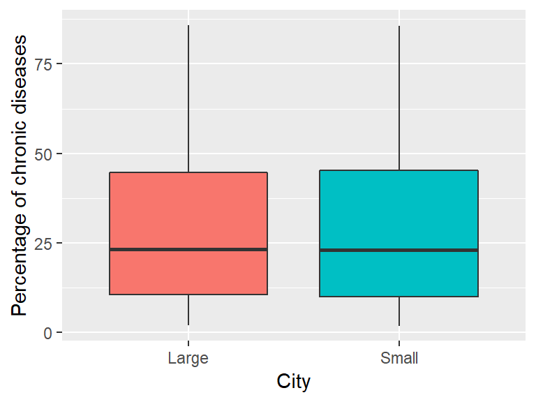

Cancer and Colorectal Cancer Screening.

- according to CDC, about 90% of new cases of colerectal cancer occurs in people who are 50 years or older.
- colorectal Cancer Screening test is used to look for the disease when a person doesn’t have symptoms.
- screening tests can be used find precancerous polyps, so that they can be removed before they turn into cancer making it the key to preventing colorectal cancer. (“Colorectal (Colon) Cancer”)

This scatter plot shows the relationship between cancer and Colorectal Cancer Screening.

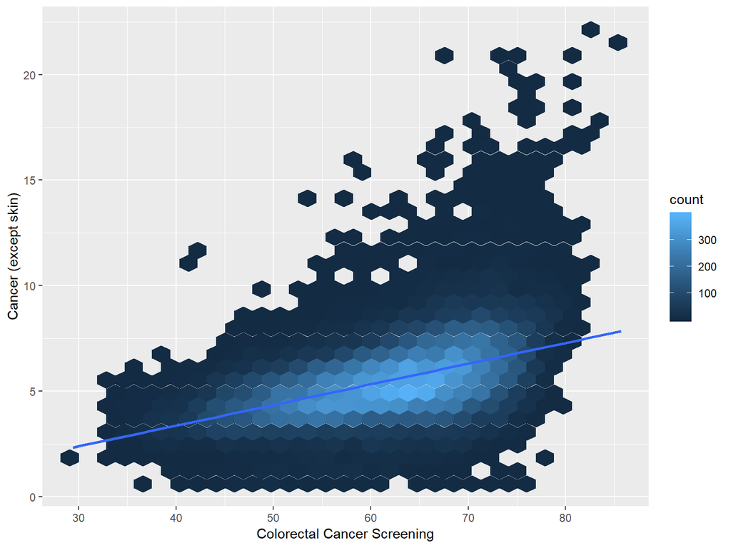

Smoking and asthma:

- the American Lung Association identifies smoking as a risk factor for developing asthma
- cigarette smoke irritates the airways, inhibiting one’s ability to breath
- those who inhale the smoke either firsthand or secondhand are at risk (“Asthma Risk Factors”)

This scatter plot shows the relationship between smoking and asthma

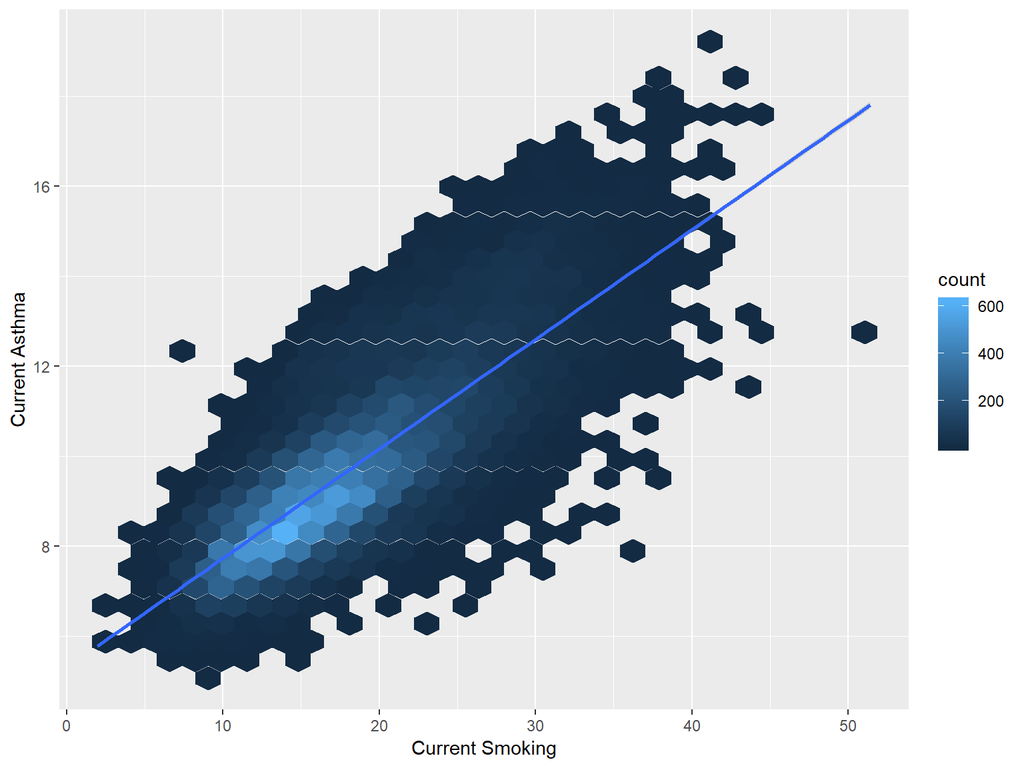

Obesity and Asthma:

This scatter plot shows the relationship between obesity and asthma

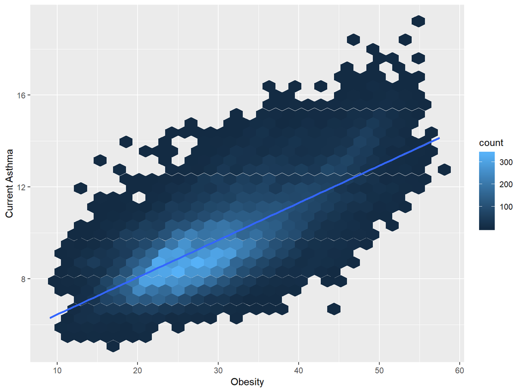

Smoking and Mental Health:

- the CDC has found that adults with mental illness smoke cigarettes more than adults who don’t (“Tobacco Use Among Adults With Mental Illness”)

This scatter plot shows the relationship between mental health and current smoking

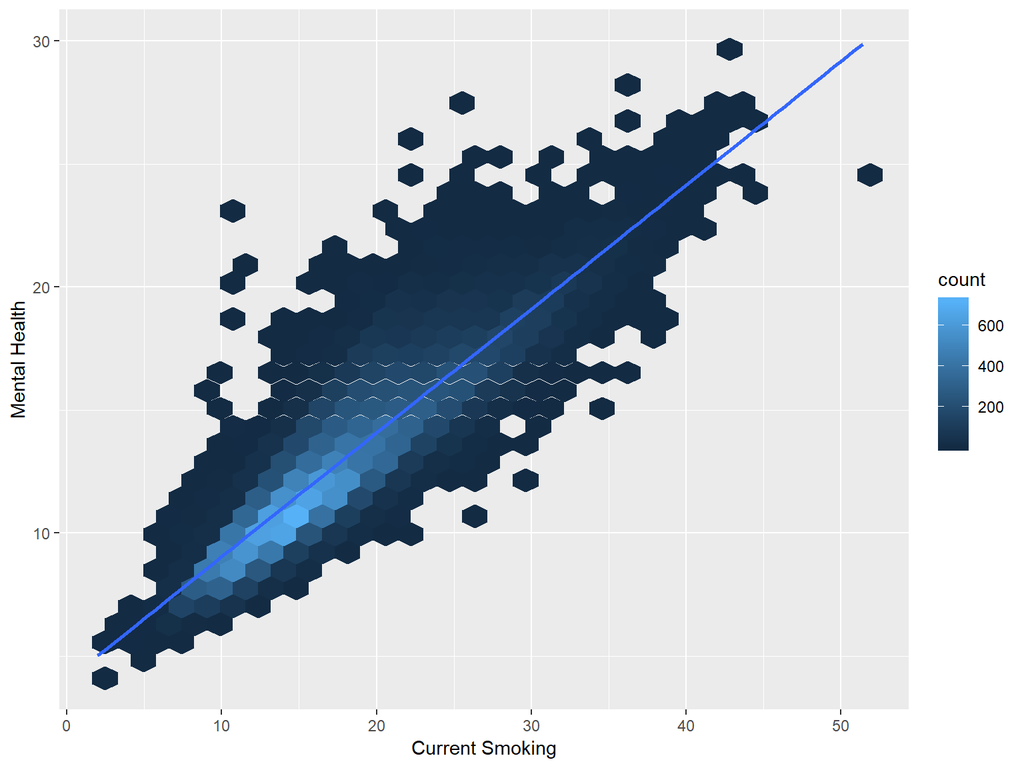

Mental health and teeth loss

- people who suffer from severe mental illness are 2.7 times more likely to lose all their teeth than the general population
- this can be because of simple things like phobia and anxiety
- serious mental illness, eating disorder or affective (mood) disorders “Kisely”

This scatter plot showing the relationship between mental health and teeth loss

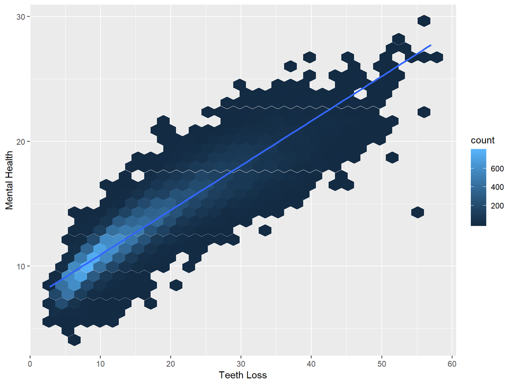

## Challenges that we have faced

- displaying the concentration of points on scatter plots
- labeling plots with LaTeX and positioning of plots
- keeping our files synced so our files are cohesive